# MSDM5002 Final Project 2023

This project features the game Gomuku (aka "Five-in-a-Row", 五子棋). You are asked to create an interactive program which you can play the game with the computer, and later compete with your classmates with your designed strategies.

## 1. Setups

### 1.1. Winning condition

To make the implementation easier, we will follow the rule of freestyle Gomoku:

- Two players take turns to place their stones (Black or White) onto the chess board. Black always goes first.
- When there are **exactly 5** stones of the same colour forming a continuous chain, the player of that colour wins the game.
- If the chain is more or less than 5 long, no one wins and the game continues.
- If there is no more available positions, the game ends in a draw. **Draw is considered as White winning** since it has been theoretically proven that Black (who goes first) has much greater advantage over White under the traditional rule.

### 1.2. Toroidal chess board

Different from the traditional $15 \times 15$ square board, you are going to play the game on a $11 \times 11$ board with a toroidal boundary condition. The chess board can be visualized as a piece of paper, is then wraped to join on the opposite sides, as illustrated:

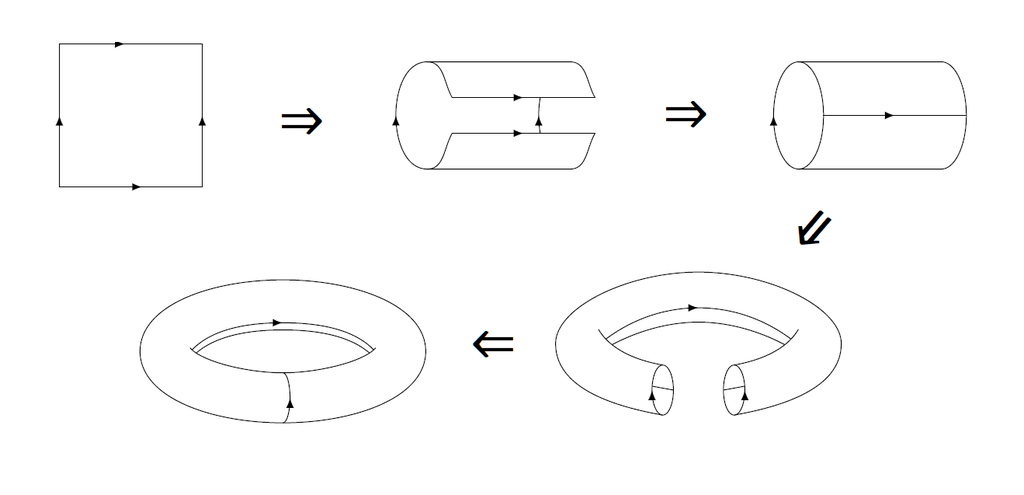

For implementation, we can imagaine the board being an infinitely large plane but players are only allow to place stones within the grid of $[0,10]\times[0,10]$. When a stone is placed at some position $(x_0,y_0)$, the "phantoms" of that stone will also be placed at all positions $(x,y)$ where $(x\bmod{11}, y \bmod{11}) = (x_0,y_0)$.

[figure not shown]

As a result, chains of 5 that cross the boundaries of the $11\times 11$ grid should also be considered as winning. For example:

[figure not shown]

## 2. Skeleton Codes

### 2.1. Board representation

The configuration of the board is represented as a nested array of size $11\times 11$. For simplicity we choose to represent it using a NumPy array, such that the coordinates on the board are exactly the same as the indices in the array.

- Initially, all positions on the board are empty, which are represented by `0`.
- Black and white stones are represented by `1` and `-1` respectively.

In the skeleton code, the variable `board` always means the matrix/nested array representation of the chess board.

```python
import numpy as np

board = np.zeros((11,11), dtype=int)

print(board)
```

```
[[0 0 0 0 0 0 0 0 0 0 0]
 [0 0 0 0 0 0 0 0 0 0 0]
 [0 0 0 0 0 0 0 0 0 0 0]
 [0 0 0 0 0 0 0 0 0 0 0]
 [0 0 0 0 0 0 0 0 0 0 0]
 [0 0 0 0 0 0 0 0 0 0 0]
 [0 0 0 0 0 0 0 0 0 0 0]
 [0 0 0 0 0 0 0 0 0 0 0]
 [0 0 0 0 0 0 0 0 0 0 0]
 [0 0 0 0 0 0 0 0 0 0 0]
 [0 0 0 0 0 0 0 0 0 0 0]]
```

### 2.2. `pygame`

We will be using the package `pygame` to create a graphical user interface. For anaconda user, since `pygame` is not pre-installed with anaconda, you have to install it manually through `pip install pygame` inside conda prompt.

```python
import pygame as pg

# import pygame for the first time will prompt this message
```

```
pygame 2.5.2 (SDL 2.28.3, Python 3.8.18)
Hello from the pygame community. https://www.pygame.org/contribute.html
```

You are not required to build the game from scratch. Most functions for the interactivity have been programmed for you. First of all, here are some utility functions for setting up the chess board. You can use them freely without understanding what they do exactly. `draw_stone()` and `print_winner()` should be the only functions you need to use in your tasks.

```python
# Drawing those dash lines outside the 11x11 board
def draw_dash_line(surface, color, start, end, width=1, dash_length=4):

    x1, y1 = start
    x2, y2 = end
    dl = dash_length

    if (x1 == x2):
        ycoords = [y for y in range(y1, y2, dl if y1 < y2 else -dl)]
        xcoords = [x1] * len(ycoords)
    elif (y1 == y2):
        xcoords = [x for x in range(x1, x2, dl if x1 < x2 else -dl)]
        ycoords = [y1] * len(xcoords)
    else:
        a = abs(x2 - x1)
        b = abs(y2 - y1)
        c = round(math.sqrt(a**2 + b**2))
        dx = dl * a / c
        dy = dl * b / c

        xcoords = [x for x in numpy.arange(x1, x2, dx if x1 < x2 else -dx)]
        ycoords = [y for y in numpy.arange(y1, y2, dy if y1 < y2 else -dy)]

    next_coords = list(zip(xcoords[1::2], ycoords[1::2]))
    last_coords = list(zip(xcoords[0::2], ycoords[0::2]))
    for (x1, y1), (x2, y2) in zip(next_coords, last_coords):
        start = (round(x1), round(y1))
        end = (round(x2), round(y2))
        pg.draw.line(surface, color, start, end, width)


####################################################################################################################
# create the initial empty chess board in the game window
def draw_board():

    global xbline, w_size, pad, sep

    xbline = bline + 8                        # Add 4 extra line on each boundaries to make chains of 5 that cross boundaries easier to see
    w_size = 720                              # window size
    pad = 36                                  # padding size
    sep = int((w_size-pad*2)/(xbline-1))      # separation between lines = [window size (720) - padding*2 (36*2)]/(Total lines (19) -1)

    surface = pg.display.set_mode((w_size, w_size))
    pg.display.set_caption("Gomuku (a.k.a Five-in-a-Row)")

    color_line = [0, 0, 0]
    color_board = [241, 196, 15]

    surface.fill(color_board)

    for i in range(0, xbline):
        draw_dash_line(surface, color_line, [pad, pad+i*sep], [w_size-pad, pad+i*sep])
        draw_dash_line(surface, color_line, [pad+i*sep, pad], [pad+i*sep, w_size-pad])

    for i in range(0, bline):
        pg.draw.line(surface, color_line, [pad+4*sep, pad+(i+4)*sep], [w_size-pad-4*sep, pad+(i+4)*sep], 4)
        pg.draw.line(surface, color_line, [pad+(i+4)*sep, pad+4*sep], [pad+(i+4)*sep, w_size-pad-4*sep], 4)

    pg.display.update()

    return surface


####################################################################################################################
# Draw the stones on the board at pos = [row, col].
# Draw a black circle at pos if color = 1, and white circle at pos if color =  -1
# row and col are be the indices on the 11x11 board array
# dark gray and light gray circles are also drawn on the dotted grid to indicate a phantom stone piece
def draw_stone(surface, pos, color=0):

    color_black = [0, 0, 0]
    color_dark_gray = [75, 75, 75]
    color_white = [255, 255, 255]
    color_light_gray = [235, 235, 235]

    matx = pos[0] + 4 + bline*np.array([[-1, 0, 1], [-1, 0, 1], [-1, 0, 1]]).flatten()
    matx1 = np.logical_and(matx >= 0, matx < xbline)
    maty = pos[1] + 4 + bline*np.array([[-1, 0, 1], [-1, 0, 1], [-1, 0, 1]]).T.flatten()
    maty1 = np.logical_and(maty >= 0, maty < xbline)
    mat = np.logical_and(np.logical_and(matx1, maty1), np.array([[True, True, True], [True, False, True], [True, True, True]]).flatten())

    if color==1:
        pg.draw.circle(surface, color_black, [pad+(pos[0]+4)*sep, pad+(pos[1]+4)*sep], 15, 0)
        for f, x, y in zip(mat, matx, maty):
            if f:
                pg.draw.circle(surface, color_dark_gray, [pad+x*sep, pad+y*sep], 15, 0)

    elif color==-1:
        pg.draw.circle(surface, color_white, [pad+(pos[0]+4)*sep, pad+(pos[1]+4)*sep], 15, 0)
        for f, x, y in zip(mat, matx, maty):
            if f:
                pg.draw.circle(surface, color_light_gray, [pad+x*sep, pad+y*sep], 15, 0)

    pg.display.update()


####################################################################################################################
def print_winner(surface, winner=0):
    if winner == 2:
        msg = "Draw! So White wins"
        color = [170,170,170]
    elif winner == 1:
        msg = "Black wins!"
        color = [0,0,0]
    elif winner == -1:
        msg = 'White wins!'
        color = [255,255,255]
    else:
        return

    font = pg.font.Font('freesansbold.ttf', 32)
    text = font.render(msg, True, color)
    textRect = text.get_rect()
    textRect.topleft = (0, 0)
    surface.blit(text, textRect)
    pg.display.update()
```

A template of the main function is given to you. First load the above functions and then the below code, you should see a game window poping out. At the moment all you can do is clicking on the board and placing the same colour of stones, and nothing else.

```python
def main_template(player_is_black=True):

    global bline
    bline = 11                  # the board size is 11x11 => need to draw 11 lines on the board

    pg.init()
    surface = draw_board()

    board = np.zeros((bline,bline), dtype=int)
    running = True
    gameover = False

    while running:

        ####################################################################################################
        ######################## Normally your edit should be within the while loop ########################
        ####################################################################################################

        for event in pg.event.get():              # A for loop to process all the events initialized by the player

            if event.type == pg.QUIT:             # terminate if player closes the game window
                running = False

            if event.type == pg.MOUSEBUTTONDOWN and not gameover:        # detect whether the player is clicking in the window

                (x,y) = event.pos                                        # check if the clicked position is on the 11x11 center grid
                if (x > pad+3.75*sep) and (x < w_size-pad-3.75*sep) and (y > pad+3.75*sep) and (y < w_size-pad-3.75*sep):
                    row = round((x-pad)/sep-4)
                    col = round((y-pad)/sep-4)

                    if board[row, col] == 0:                             # update the board matrix if that position has not been occupied
                        color = 1 if player_is_black else -1
                        board[row, col] = color
                        draw_stone(surface, [row, col], color)



        ####################################################################################################
        ######################## Normally Your edit should be within the while loop ########################
        ####################################################################################################

    pg.quit()


if __name__ == '__main__':
    main_template(True)
```

**Note:** When you encounter an error while testing your code, the pygame window will freeze. Trying to close the window will force python to restart the kernal. To avoid this, you have to manually run `pg.quit()` in the console/another notebook cell to kill the process.

```python
pg.quit()
```

## 3. Tasks

Your tasks are to complete the functionalities of the game. This is a group project and we expect each group to have at most 4 people (you are welcome to work alone though).

### 3.1. Player vs AI

You have to write at least 3 functions:

- `main()` - The main function that runs the game. You can start by editing the `main_template()` function.
- `check_winner()` - For checking if any of the color wins after each placement.
- `ai_move()` - Control how your AI places the stones, given that it knows the board's current configurtaion.

```python
def main(player_is_black=True):
    # The only input argument `player_is_black` is to determine if player or the AI goes first
    # Only the game window pop out. No output is required


def check_winner(board):
    # Input: board = current configuration of the 11x11 matrix
    # Output: 1 or -1 to indicate which color wins; 2 if it is a draw; 0 if the game is not yet over


def ai_move(board, color):
    # Input: board = current configuration of the 11x11 matrix
    #        color = the stone color of the AI
    # Output: [row, col] = a 1x2 array to indicate where the AI should place its next stone
```

Your program should run as follow:

1. Run `main()` to start the game.
2. If `player_is_black` is set to `True`, it waits until the player placing his first black stone. Otherwise the AI places the first black stone.
3. Then player and AI take turns to place their stones. When the AI decides its move, it will call the `ai_move` function to output its placing position. The execution of `ai_move()` should not take more than 5 seconds.
   - The main strategy of the AI should be based on **Monte Carlo Tree Search (MCTS)**
   - You can add other strategies to improve its winning rate. For example, try to occupy the position where your opponent is going to win if he takes that position in the next move.
1. After each placement (both player and AI), the program should call `check_winner` to check if any of the colours wins. If yes, then use `print_winner()` to display `Black wins!`, `White wins!`, or `Draw!` in the game window. The screen should then be locked and any player clicking can no longer change the board.
2. Player should be allowed to close the game window at any time.

### 3.2. AI vs AI

At the end of the semester, we will have hold a knockout competition between the AI from each groups. In each battle, I will run a code similar to the one below. The 4 groups who get into the semi-final round will receive bonus marks.

```
# This is just a draft. Subject to change later. This is your TA's task.

from group1 import *
from group2 import *

def battle(ai_move1, ai_move2):

    global bline
    bline = 11

    pg.init()
    surface = draw_board()

    board = np.zeros((bline,bline), dtype=int)
    running = True
    gameover = False

    while running:

        for event in pg.event.get():

            if event.type == pg.QUIT:
                running = False

        if not gameover:
            [row, col] = ai_move1(board, 1)            # First group is assigned to be black
            if board[row, col] == 0:
                board[row, col] = 1
                draw_stone(surface, [row, col], 1)
            gameover = check_winner(board)

        if not gameover:
            [row, col] = ai_move2(board, -1)           # Second group is assigned to be white
            if board[row, col] == 0:
                board[row, col] = -1
                draw_stone(surface, [row, col], -1)
            gameover = check_winner(board)

        if gameover:
            print_winner(surface, gameover)


    pg.quit()


if __name__ == '__main__':
    battle(group1.ai_move, group2.ai_move)
```

### 3.3 Submission & Deadlines

**By Dec 4 23:59**

- Your code (for each group) - **ONE single `.py` file** that contains the 3 required functions in your tasks, all the utility functions provided to you, and anything else you added to run your AI.
- Your report (for each person) - A short report (in PDF, expect 2-4 pages but not mandatory) that contains
  - Your understanding to MCTS
  - Your contribution in the project
  - A peer evaluation table to give each of your groupmate a participation score (scale: 0-5)

    Not submitting the peer evaluation may result in losing your own peer evaluation score.

**On Dec 8 19:00**

We will hold the inter-group battle session in the classroom . You do not have to prepare anything except snacks and drinks :)